# Studying Cumulative COVID Cases in the USA

Udirno Chaudhuri: 916895451, Team id: 10

03/14/2022

## Data Background and Introduction

WHO COVID-19 data:

We will explore the WHO COVID-19 data in this project. You can take a look at the [weekly WHO COVID-19 update](https://www.who.int/emergencies/diseases/novel-coronavirus-2019/situation-reports) for reference.

The Coronavirus, originated from the SARS-CoV-2 virus was first discovered back in 2019. It is a highly contagious virus that causes sever negative respiratory symptoms similar to pneumonia and the flu. Since then the virus has been declared a global pandemic and the illness has caused millions of deaths worldwide. Although the pandemic has become more controlled in the last year, there is a lot fear revolving its unpredictability. We hope to use the WHO data provided to gain insight as to its trends so we can potentially avoid any more surprises.

This data set is maintained by WHO and updated constantly with already over 189420 observations across 8 variables. The variables we chose decided to choose of interest are “Date Reported”, “Cumulative Cases”, “Cumulative Deaths”, additionally we plan to calculate the mortality rate as cumulative deaths/cumulative cases in order to make analysis easier.

For our project we will explore a Coronavirus data set provided by the WHO. It is updated daily and the source is credible. The data set provides the weekly Epidemiological update of the coronavirus across global countries. We want to use this information to explore the relationship between the mean cumulative coronavirus cases in the USA and the time of year. We are going to segment the “Date Reported” variable into 3 segments (Jan-Apr, May-Aug, Sep-Dec) and specifically only look at cases in the year 2021. We will observe the “Cumulative Cases” in those time frames for our specific modelto determine which range of months is worse or better in terms of cumulative coronavirus cases in just the USA. This will help to determine trends in covid cases throughout the year based on our monthly ranges. This will allow us to better equip ourselves against the coronavirus similar to how we already do with the cyclic “flu season”. The goal is to use a single factor ANOVA model to observe mean cumulative covid cases in the USA throughout the year. We will also continue our analysis by fitting another alternative model, a two factor ANOVA model to compare covid case surges in the USA with another country: India.

## Questions of Interest

1. How does the time of year affect the mean number of cumulative covid cases in America, specifically in the year 2021?
2. We will examine the mean cumulative covid cases using a single factor ANOVA model to answer the question stated above. Additionally, we will also fit a two factor ANOVA model to compare mean cumulative covid cases between the USA and India so that we can gain some insight to answer the question: how have different regions of the world reacted to the pandemic? Visualizations will include “Cumulative Cases”, “Cumulative Deaths” and “Mortality Rates” in an effort to understand the data being given.
3. Does country (India vs USA) have an affect on the number of covid cases across 12 months?

## Introducing our Data Set

```
##  Date_reported        Country_code         Country           WHO_region
##  Min.   :2020-01-03   Length:190074      Length:190074      Length:190074
##  1st Qu.:2020-07-21   Class :character   Class :character   Class :character
##  Median :2021-02-06   Mode  :character   Mode  :character   Mode  :character
##  Mean   :2021-02-06
##  3rd Qu.:2021-08-26
##  Max.   :2022-03-14
##    New_cases       Cumulative_cases     New_deaths      Cumulative_deaths
##  Min.   : -32952   Min.   :       0   Min.   : -60.00   Min.   :     0
##  1st Qu.:      0   1st Qu.:     146   1st Qu.:   0.00   1st Qu.:     1
##  Median :     22   Median :    9454   Median :   0.00   Median :   128
##  Mean   :   2403   Mean   :  538413   Mean   :  31.79   Mean   : 10880
##  3rd Qu.:    508   3rd Qu.:  142264   3rd Qu.:   6.00   3rd Qu.:  2445
##  Max.   :1294746   Max.   :78777620   Max.   :8786.00   Max.   :960144
```

We will only be focusing on a few of these variables, the rest are to just show the extent to which COVID data is being collected and potential further analysis. Using the variables we select we will first have to satisfy the assumptions and conditions associated with our proposed models.

```
## [1] 0.01794218 0.01792432 0.01787225 0.01778962 0.01771198 0.01766299
```

```
## [1] 0.01448413 0.01447905 0.01447457 0.01447217 0.01446869 0.01446891
```

Notice we have displayed the first 6 values for COVID mortality rates in the USA and India respectively. These can be interpreted as percentages.

## Additional Summary Statistics by time period

In order to make our analysis cleaner and more interpretable, we have grouped each of the 12 months into a three separate ranges of months for which we plan to observe the summary statistics as an initial effort to identify any overall trends in the data.

5 number summary for the months January through April in the U.S.:

```r
summary(jan_april_usa)
```

```
##  Date_reported        Country_code         Country           WHO_region
##  Min.   :2021-01-01   Length:120         Length:120         Length:120
##  1st Qu.:2021-01-30   Class :character   Class :character   Class :character
##  Median :2021-03-01   Mode  :character   Mode  :character   Mode  :character
##  Mean   :2021-03-01
##  3rd Qu.:2021-03-31
##  Max.   :2021-04-30
##    New_cases      Cumulative_cases     New_deaths     Cumulative_deaths
##  Min.   : 30496   Min.   :19818218   Min.   : 368.0   Min.   :355582
##  1st Qu.: 58151   1st Qu.:25827266   1st Qu.: 816.5   1st Qu.:450936
##  Median : 70726   Median :28427792   Median :1546.0   Median :521880
##  Mean   :103029   Mean   :27672070   Mean   :1849.2   Mean   :498533
##  3rd Qu.:138802   3rd Qu.:30126574   3rd Qu.:2780.2   3rd Qu.:553170
##  Max.   :293313   Max.   :31944206   Max.   :5074.0   Max.   :573727
##      month
##  Min.   :1.00
##  1st Qu.:1.00
##  Median :3.00
##  Mean   :2.50
##  3rd Qu.:3.25
##  Max.   :4.00
```

5 number summary for the months May through August in the U.S.:

```r
summary(may_aug_usa)
```

```
##  Date_reported        Country_code         Country           WHO_region
##  Min.   :2021-05-01   Length:123         Length:123         Length:123
##  1st Qu.:2021-05-31   Class :character   Class :character   Class :character
##  Median :2021-07-01   Mode  :character   Mode  :character   Mode  :character
##  Mean   :2021-07-01
##  3rd Qu.:2021-07-31
##  Max.   :2021-08-31
##    New_cases      Cumulative_cases     New_deaths     Cumulative_deaths
##  Min.   :  8335   Min.   :32000132   Min.   : 106.0   Min.   :574485
##  1st Qu.: 15592   1st Qu.:32931674   1st Qu.: 302.0   1st Qu.:591278
##  Median : 32135   Median :33327329   Median : 417.0   Median :600885
##  Mean   : 55807   Mean   :34042957   Mean   : 548.1   Mean   :601839
##  3rd Qu.: 91196   3rd Qu.:34738822   3rd Qu.: 676.5   3rd Qu.:609946
##  Max.   :186309   Max.   :38808503   Max.   :1833.0   Max.   :641147
##      month
##  Min.   :5.000
##  1st Qu.:5.500
##  Median :7.000
##  Mean   :6.504
##  3rd Qu.:7.500
##  Max.   :8.000
```

5 number summary for the months September through December in the U.S.:

```r
summary(sept_dec_usa)
```

```
##  Date_reported        Country_code         Country           WHO_region
##  Min.   :2021-09-01   Length:122         Length:122         Length:122
##  1st Qu.:2021-10-01   Class :character   Class :character   Class :character
##  Median :2021-10-31   Mode  :character   Mode  :character   Mode  :character
##  Mean   :2021-10-31
##  3rd Qu.:2021-11-30
##  Max.   :2021-12-31
##    New_cases      Cumulative_cases     New_deaths   Cumulative_deaths
##  Min.   : 22672   Min.   :38941538   Min.   : 172   Min.   :642350
##  1st Qu.: 81584   1st Qu.:43131636   1st Qu.:1067   1st Qu.:698330
##  Median :108496   Median :45659813   Median :1482   Median :744288
##  Mean   :120648   Mean   :45696643   Mean   :1451   Mean   :737233
##  3rd Qu.:138510   3rd Qu.:48151302   3rd Qu.:1948   3rd Qu.:776525
##  Max.   :473047   Max.   :53527519   Max.   :3871   Max.   :818171
##      month
##  Min.   : 9.00
##  1st Qu.:10.00
##  Median :10.50
##  Mean   :10.51
##  3rd Qu.:11.75
##  Max.   :12.00
```

5 number summary for the months January through April in India:

```r
summary(jan_april_india)
```

```
##  Date_reported        Country_code         Country           WHO_region
##  Min.   :2021-01-01   Length:120         Length:120         Length:120
##  1st Qu.:2021-01-30   Class :character   Class :character   Class :character
##  Median :2021-03-01   Mode  :character   Mode  :character   Mode  :character
##  Mean   :2021-03-01
##  3rd Qu.:2021-03-31
##  Max.   :2021-04-30
##    New_cases      Cumulative_cases     New_deaths     Cumulative_deaths
##  Min.   :  8635   Min.   :10286709   Min.   :  77.0   Min.   :148994
##  1st Qu.: 13776   1st Qu.:10742920   1st Qu.: 112.2   1st Qu.:154242
##  Median : 18200   Median :11118384   Median : 165.0   Median :157202
##  Mean   : 70802   Mean   :11909492   Mean   : 496.6   Mean   :161203
##  3rd Qu.: 69098   3rd Qu.:12167418   3rd Qu.: 377.0   3rd Qu.:162583
##  Max.   :386452   Max.   :18762976   Max.   :3645.0   Max.   :208330
##      month
##  Min.   :1.00
##  1st Qu.:1.00
##  Median :3.00
##  Mean   :2.50
##  3rd Qu.:3.25
##  Max.   :4.00
```

5 number summary for the months May through August in India:

```r
summary(may_aug_india)
```

```
##  Date_reported        Country_code         Country           WHO_region
##  Min.   :2021-05-01   Length:123         Length:123         Length:123
##  1st Qu.:2021-05-31   Class :character   Class :character   Class :character
##  Median :2021-07-01   Mode  :character   Mode  :character   Mode  :character
##  Mean   :2021-07-01
##  3rd Qu.:2021-07-31
##  Max.   :2021-08-31
##    New_cases      Cumulative_cases     New_deaths   Cumulative_deaths
##  Min.   : 25072   Min.   :19164969   Min.   : 350   Min.   :211853
##  1st Qu.: 39229   1st Qu.:28111289   1st Qu.: 534   1st Qu.:330498
##  Median : 46148   Median :30411634   Median :1005   Median :399459
##  Mean   :113869   Mean   :29242628   Mean   :1872   Mean   :371596
##  3rd Qu.:143444   3rd Qu.:31634908   3rd Qu.:3486   3rd Qu.:424080
##  Max.   :414188   Max.   :32768880   Max.   :6148   Max.   :438560
##      month
##  Min.   :5.000
##  1st Qu.:5.500
##  Median :7.000
##  Mean   :6.504
##  3rd Qu.:7.500
##  Max.   :8.000
```

5 number summary for the months September through December in India:

```r
summary(sept_dec_india)
```

```
##  Date_reported        Country_code         Country           WHO_region
##  Min.   :2021-09-01   Length:122         Length:122         Length:122
##  1st Qu.:2021-10-01   Class :character   Class :character   Class :character
##  Median :2021-10-31   Mode  :character   Mode  :character   Mode  :character
##  Mean   :2021-10-31
##  3rd Qu.:2021-11-30
##  Max.   :2021-12-31
##    New_cases     Cumulative_cases     New_deaths     Cumulative_deaths
##  Min.   : 5326   Min.   :32810845   Min.   : 125.0   Min.   :439020
##  1st Qu.: 8910   1st Qu.:33772796   1st Qu.: 244.5   1st Qu.:448398
##  Median :13074   Median :34279557   Median : 304.0   Median :458312
##  Mean   :16967   Mean   :34135756   Mean   : 348.5   Mean   :459079
##  3rd Qu.:22739   3rd Qu.:34594538   3rd Qu.: 392.8   3rd Qu.:469180
##  Max.   :47092   Max.   :34838804   Max.   :2796.0   Max.   :481080
##      month
##  Min.   : 9.00
##  1st Qu.:10.00
##  Median :10.50
##  Mean   :10.51
##  3rd Qu.:11.75
##  Max.   :12.00
```

Next let us look at the plots of each of our three main variables: Cumulative Cases, Cumulative Deaths, and Mortality Rates. We will prepare two plots for each variable. A line graph to make it easier to observe smaller variations in trend followed by a bar graph that is grouped into three groups based on the range of months we discussed previously i.e. Group 1 (Jan-Apr), Group 2 (May-Aug), Group 3 (Sep - Dec).

## Cumulative Cases Plots:

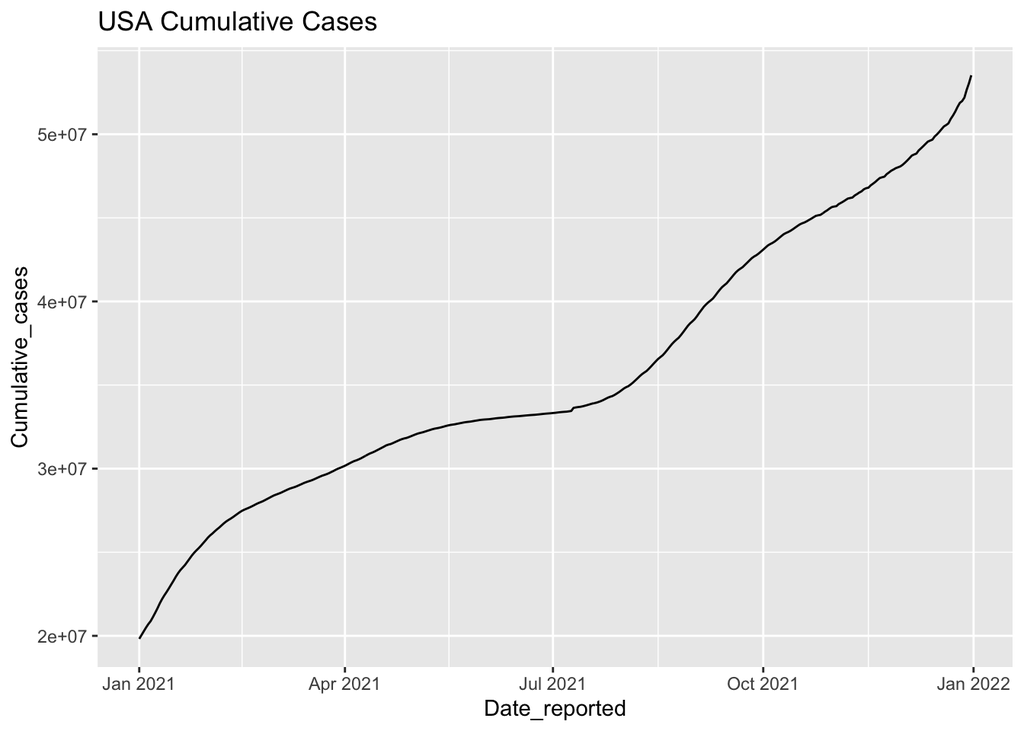

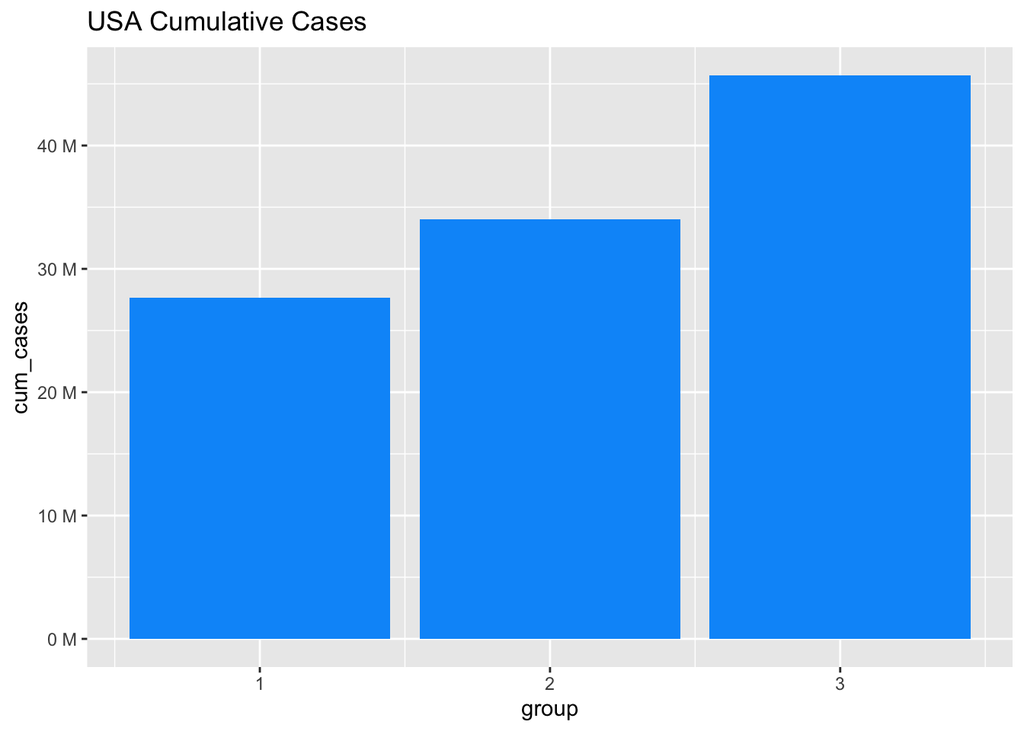

The independent variable in this case is the date reported and the dependent variable is the number of total cases in the USA. Observe the trend in the US Cumulative COVID Cases graph. The curve is relatively linear and follows a positive trend. We can quickly make some obvious observations based on this visualization. For example between Jan 2021 and Jan 2022 the cumulative number of cases more than doubled.

The more general bar graphs show a clear increase in cumulative across all three USA groups. Group 3 had a max of over 45 million and the increase supports the linear trend shown in the line graph.

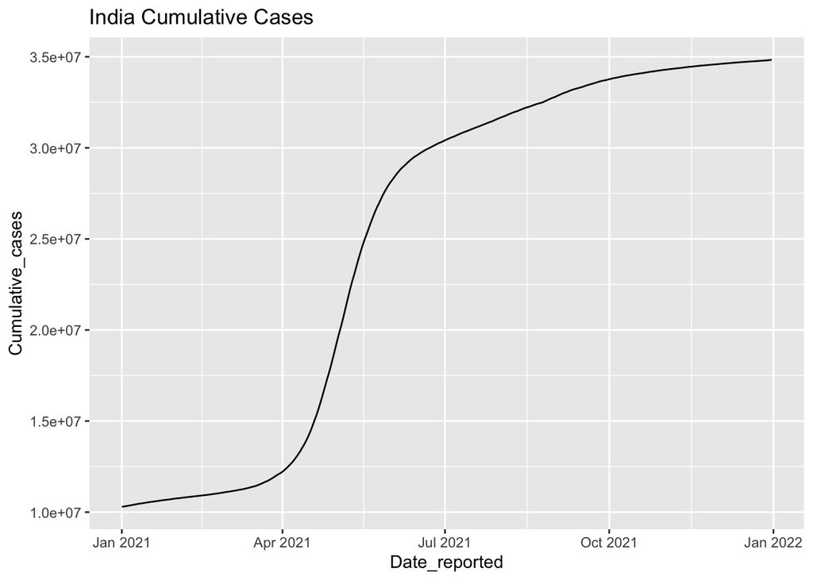

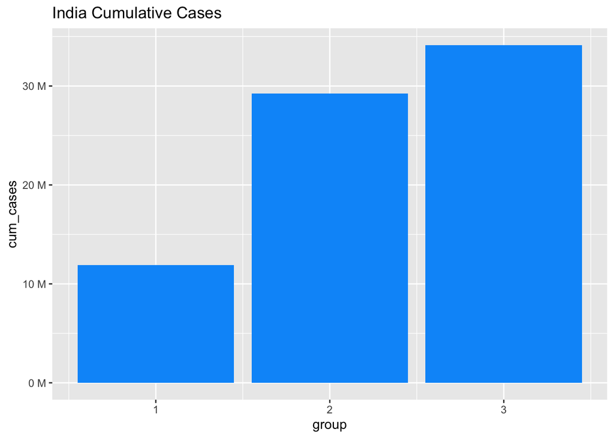

Similarly here the independent variable is the date reported and the dependent variable is the number of total cases in India. Observe the trend in India’s Cumulative COVID Cases graph. The curve is not linear and instead grows exponentially before plateauing out. All throughout however, the number of cases is increasing. We can quickly make some obvious observations based on this visualization. For example between Jan 2021 and Jan 2022 the cumulative number of covid cases in India more than tripled.

This bar graph shows a sharp jump between group 1 and group 2 which is also reflected in the line graph. We notice that the scale of cumulative cases for India is smaller however the rate at which cumulative cases increased is more rapid than the USA.

## Cumulative Deaths Plots:

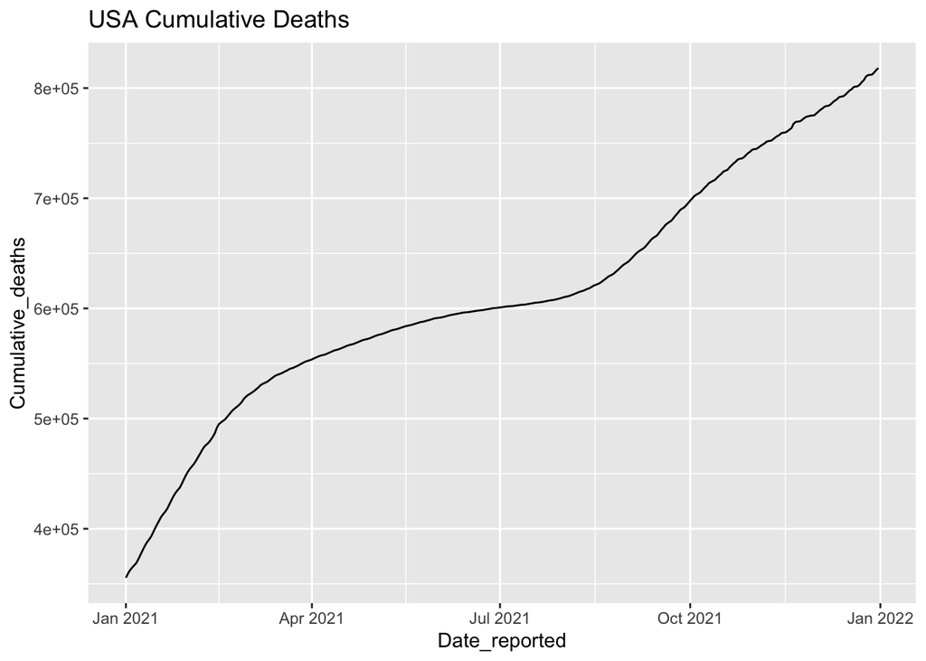

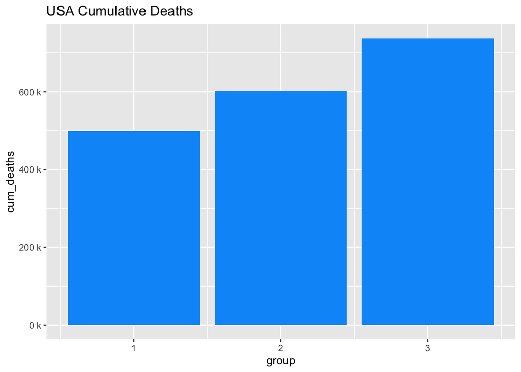

Perhaps the most important variable for our analysis, cumulative deaths in the USA is plotted as the dependent variable against date reported, our independent variable. The graph shows a relatively positive linear trend with the cumulative number of deaths approximately doubling over the period of 12 months.

In the bar graph above, USA Cumulative Deaths increases in a steady positive linear trend across all three groups. From first glance, before fitting any model we can see that there does not appear to be any anomalies in the data other than that cumulative deaths shows no signs of slowing down which is alarming.

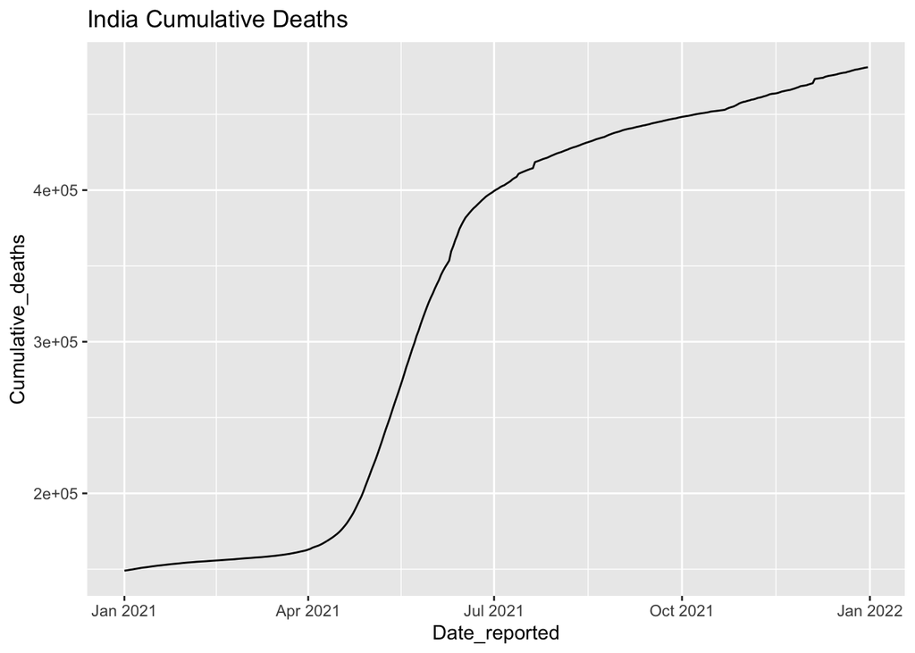

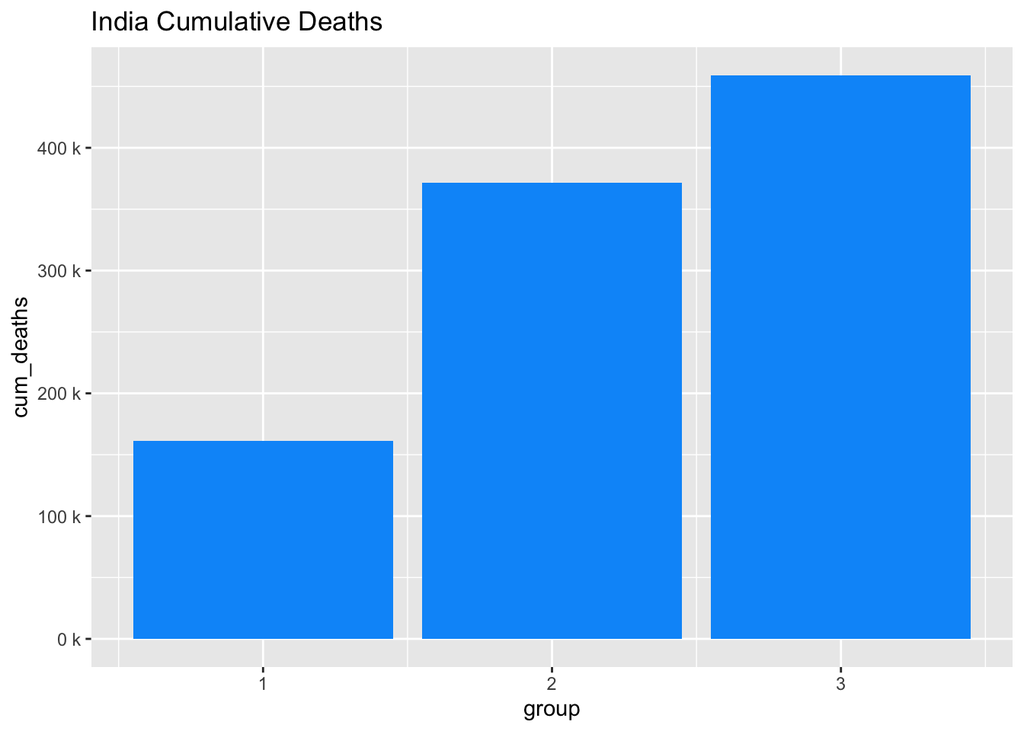

Similarly, in this graph the cumulative deaths in India is plotted as the dependent variable against date reported, our independent variable. The graph shows positive exponential trend that eventually plateaus out. Observe that the cumulative number of deaths in India more than triples over the period of 12 months.

The cumulative deaths bar graph for India also reflects its respective line graph showing a sharp exponential increase between group 1 and 2. That suggests that between the months of April and May there is significant change in the number of cumulative covid deaths in India.

## Mortality Rates Plots:

To combine the two previous variables we calculated a mortality rate by dividing (cumulative deaths)/(cumulative cases). The mortality basically gives us a percentage for the number of deaths ina ceratin region of our two populations. We will be looking at the mortality rates for the USA and India.

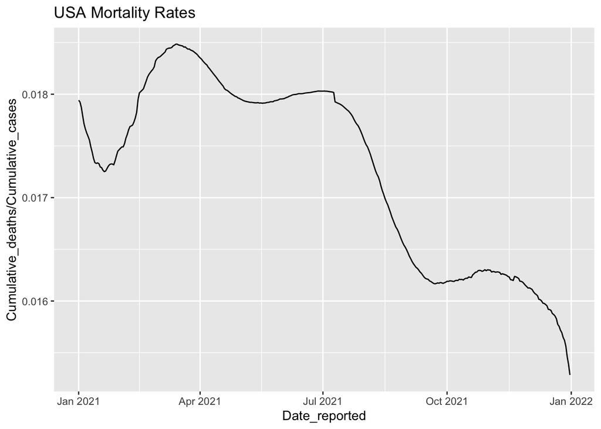

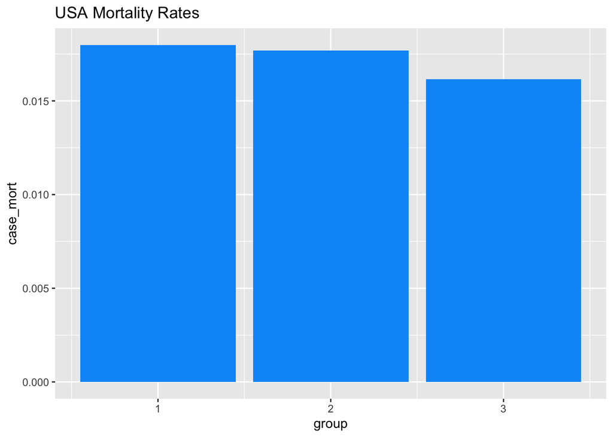

The overall trend for USA mortality rate is declining however it does so irregularly. The mortality rate shot up between Feb and Apr of 2021 before shooting back down shortly after, almost exponentially. A decline in the mortality rate tells us that the number of people dying is decreasing which is good news but the rate at which it is decreasing is not constant/linear.

This bar graph is interesting because it shows that mortality rate is relatively constant across all three groups. There is a decline overall however it is far less drastic compared to the other trends we have observed thus far with our other variables. Group 3 does have the lowest mortality rate which is and although the rate of decline is slow it is reassuring to see that it is going down.

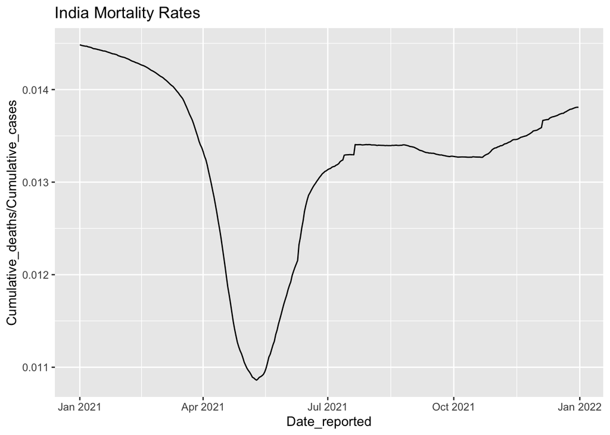

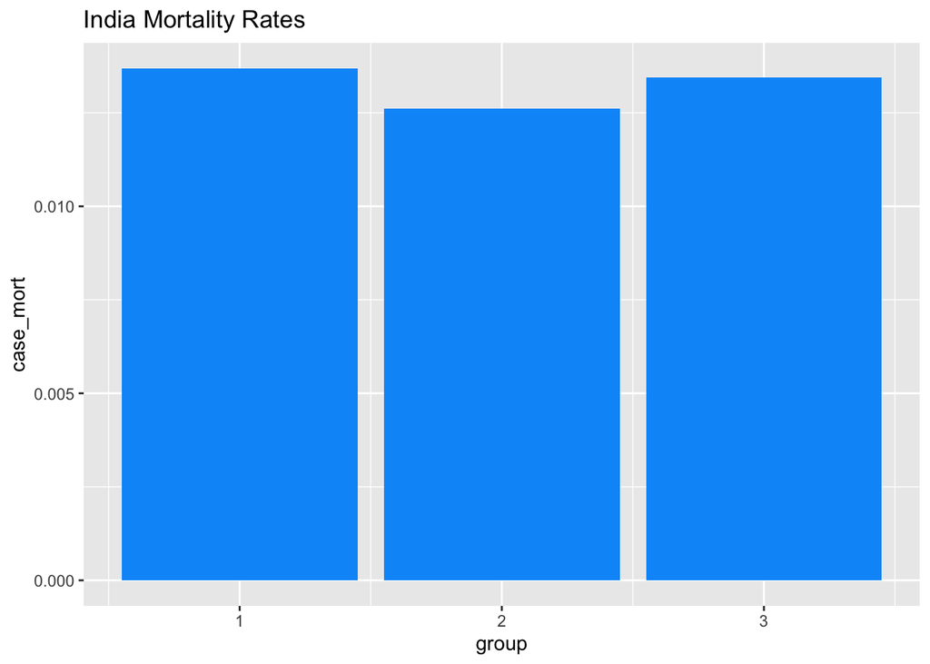

The trend for India’s mortality rate is slightly alarming based on our merged data. Initially there is a sharp drop in mortality rate after April 2021 however instead of staying low it exponentially shoots back up before plateauing. Based on the latest data from Jan 2022 it appears that the mortality rate is also on the rise which is unusual and alarming for India.

When observing the monthly range bar graph for mortality rates in India we observe that there is an increase in mortality rate between group 2 and 3. This indicates that more people died at a higher rate from covid between August and September 2021 even with the introduction of the vaccine. This is not the same trend as the USA mortality rate which declined with each progressive group. This is alarming for India and the question should defintely be raised as to why mortality rate increased in group 3 despite a decrease from group 1 to group 2.

## Additional Monthly Boxplot visualizations

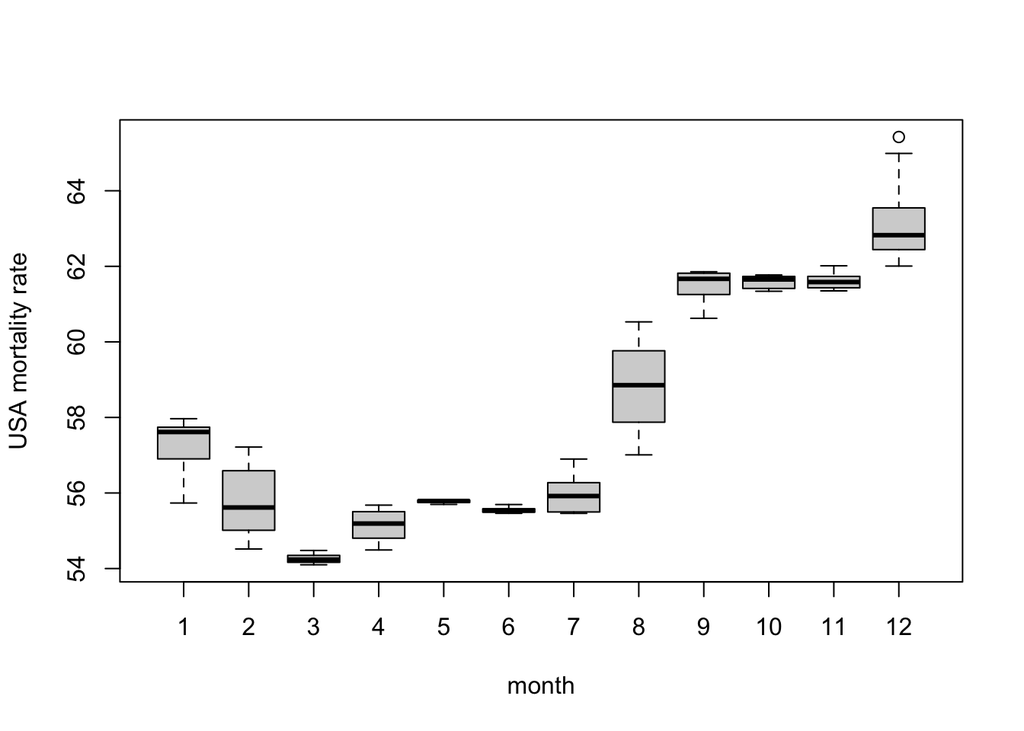

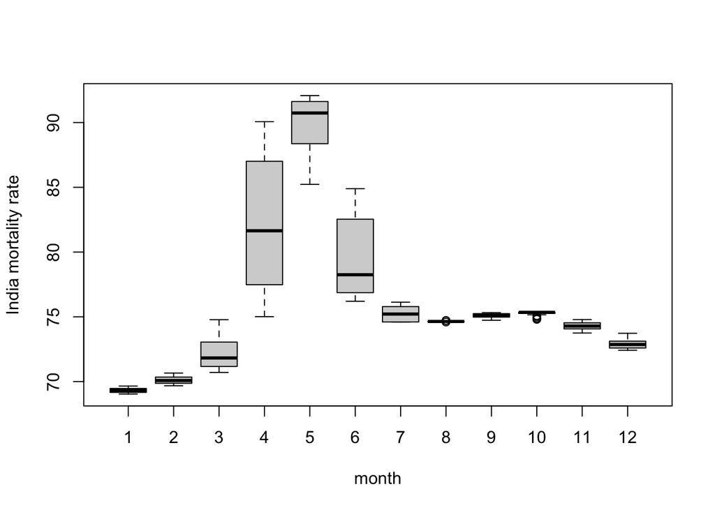

## Proposed Model and Sensitivity Analysis

Our first proposed model will be the single factor ANOVA model. The factor will be the time of year (i.e. Jan-Apr) and we will observe any difference in the mean cumulative COVID cases in the USA between each time period.

Assumptions of Single Factor ANOVA: - Individual samples are taken from normally distributed population - Individual samples are independently drawn (random sampling) - Variance is the same across different groups (homegeneity) - Continuous dependent variable (cumulative COVID cases)

Hypotheses of interest in our single factor ANOVA are as follows:

H0: u1 = u2 = u3 … = uk mean cumulative cases across all months are equal. (not significant) H1: Mean cumulative cases across all months are not all equal. (significant)

where k = # of independent comparison groups (months/groups)

Our second proposed model is similar but will be a two factor ANOVA model. The same assumptoins apply the only difference is that we include another factor, a new country which will be India. This model is intended to help us answer our question of interest regarding the effect of region on cumulative covid cases since now we are observing it on an international scale.

Assumptions of Two Factor ANOVA (same as single factor): - Individual samples are taken from normally distributed population - Individual samples are independently drawn (random sampling) - Variance is the same across different groups (homegeneity) - Continuous dependent variable (cumulative COVID cases)

## Shapiro Wilk Test

The purpose of running a Shapiro Wilk Test is to test for the normality of our population in order to satisfy the first assumption of ANOVA which is that the samples are taken from a populatoin that is normally distributed. (Additionally, since our sample size is also greater than 30 the central limit theorem supports our assumption even though we do not explicitly show it here)

H0: The population is normally distributed HA: The population is not normally distributed

We will also visualize a Q-Q plot in order to test for normality of mean Covid Cases in the USA to further satisfy this condition.

The Random Sampling condition is met because we are going to randomly sample 50 observations from each group(1,2,3) for the USA and India however that will only be for the two way ANOVA model.

The Homogenity of variance condition is only met for our single factor ANOVA model because the residuals of our single factor ANOVA model are centered relatively constantly around 0.

Single Factor ANOVA:

```r
# One-way ANOVA
res_aov <- aov(Cumulative_cases ~ group, data = sample_usa)
summary(res_aov)
```

```
##              Df    Sum Sq   Mean Sq F value Pr(>F)
## group         1 8.329e+15 8.329e+15   772.4 <2e-16 ***
## Residuals   148 1.596e+15 1.078e+13
## ---
## Signif. codes:  0 '***' 0.001 '**' 0.01 '*' 0.05 '.' 0.1 ' ' 1
```

```r
res_aov1 <- aov(Cumulative_deaths ~ group, data=sample_usa)
```

The p-value of our Single Factor ANOVA model <2e-16 indicating we can reject H0 and conclude that there is a significant difference in the mean cumulative covid cases across at least two months.

Square Root Transformations to attempt to satisfy conditions:

```r
# Sq. Rt transformation
sample_india$Cumulative_cases <- (sample_india$Cumulative_cases)^(1/2)
res_aov1 <- aov(Cumulative_cases ~ group + Country, data = merged_country)
two_way_res1<-resid(res_aov1)
shapiro.test(two_way_res1)
```

```
##
##  Shapiro-Wilk normality test
##
## data:  two_way_res1
## W = 0.92573, p-value = 5.068e-07
```

Two Way ANOVA:

```r
# Two-way ANOVA
two.way <- aov(Cumulative_cases ~ group + Country, data = merged_country)
summary(two.way)
```

```
##              Df    Sum Sq   Mean Sq F value Pr(>F)
## group         1 1.012e+16 1.012e+16   797.9 <2e-16 ***
## Country       1 4.206e+15 4.206e+15   331.7 <2e-16 ***
## Residuals   147 1.864e+15 1.268e+13
## ---
## Signif. codes:  0 '***' 0.001 '**' 0.01 '*' 0.05 '.' 0.1 ' ' 1
```

# AIC and Model Selection

```r
# AIC used to determine the best model
AIC(res_aov, two.way)
```

```
##         df      AIC
## res_aov  3 4931.019
## two.way  4 4956.323
```

## Sensitivity Analysis and Residual Plots

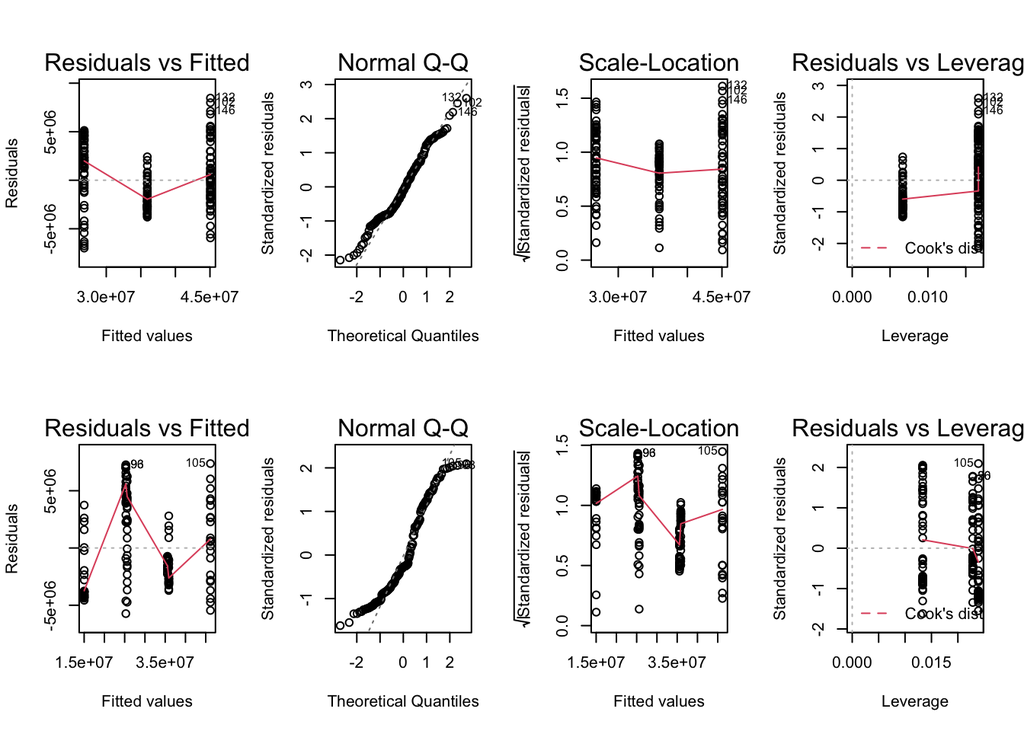

```
##
##  Shapiro-Wilk normality test
##
## data:  one_way_res
## W = 0.92573, p-value = 5.068e-07
```

```
##
##  Shapiro-Wilk normality test
##
## data:  two_way_res
## W = 0.92573, p-value = 5.068e-07
```

Our two way ANOVA model is invalid only because the homogeneity of variance condition was not met, however it is still worth visualizing the respective residual plots. There appear to be significant outliers present on the tail ends of the normal Q-Q plot for both models especially this one. Notice how the graph of fitted values when compared to that of the single factor ANOVA model is much more volatile for the two way ANOVA model. This further supports our invalidity of the variance condition.

## Conclusion

It makes sense to reiterate our questions of interest:

1. How does the time of year affect the mean number of cumulative covid cases in America, specifically in the year 2021?
2. We will examine the mean cumulative covid cases using a single factor ANOVA model to answer the question stated above. Additionally, we will also fit a two factor ANOVA model to compare mean cumulative covid cases between the USA and India so that we can gain some insight to answer the question: how have different regions of the world reacted to the pandemic? Visualizations will include “Cumulative Cases”, “Cumulative Deaths” and “Mortality Rates” in an effort to understand the data being given.
3. Does country (India vs USA) have an affect on the number of covid cases across 12 months?

We made the decision that a Single factor ANOVA model would be appropriate with respect to time. Single factor ANOVA tests for statistical significance between the means of independent groups. In our case we had time as months throughout the year. For example, in our situation we can test against the null Hypothesis H0: Mean cumulative COVID cases in the USA are equal across all months. We wanted to understand how the mean cumulative cases varied within the 3 range of months we selected and a single factor ANOVA model is designed to do just that.

Group Collab partners: Adarsh Pantula, Tarun Devesetti

```r
library(tidyverse)
library(dplyr)
library(ggplot2)
covid <- read_csv("https://covid19.who.int/WHO-COVID-19-global-data.csv")
summary(covid)

usa_covid <- covid %>% filter(Country == "United States of America")
india_covid <- covid %>% filter(Country == "India")

# Sub-setting the USA data into monthly time periods using index
jan_april_usa <- usa_covid[c(365:484),]
may_aug_usa <- usa_covid[c(485:607),]
sept_dec_usa <- usa_covid[c(608:729),]

# Sub-setting the India data into monthly time periods using index
jan_april_india <- india_covid[c(365:484),]
may_aug_india <- india_covid[c(485:607),]
sept_dec_india <- india_covid[c(608:729),]

# Adding a month column for each month - USA
jan_april_vec <- rep(c(1,2,3,4),times = c(31,28,31,30))
jan_april_usa$month <- jan_april_vec
# jan_april_vec

may_aug_vec <- rep(c(5,6,7,8), times = c(31,30,31,31))
may_aug_usa$month <- may_aug_vec

sept_dec_vec <- rep(c(9,10,11,12), times = c(30,31,30,31))
# sept_dec_vec
sept_dec_usa$month <- sept_dec_vec

# Adding a month column for each month - India
jan_april_vec <- rep(c(1,2,3,4),times = c(31,28,31,30))
jan_april_india$month <- jan_april_vec

may_aug_vec <- rep(c(5,6,7,8), times=c(31,30,31,31))
may_aug_india$month <- may_aug_vec

sept_dec_vec <- rep(c(9,10,11,12), times=c(30,31,30,31))
sept_dec_india$month <- sept_dec_vec

merged_usa <- rbind(jan_april_usa,may_aug_usa)
merged_usa <- rbind(merged_usa,sept_dec_usa)

merged_india <- rbind(jan_april_india, may_aug_india)
merged_india <- rbind(merged_india,sept_dec_india)

group_vec <- rep(c(1,2,3), times=c(120, 123, 122))
merged_usa$group <- group_vec
merged_india$group <- group_vec

mortality_rate_usa <- merged_usa$Cumulative_deaths/merged_usa$Cumulative_cases
mortality_rate_india <- merged_india$Cumulative_deaths/merged_india$Cumulative_cases
head(merged_usa$mort_rate <- mortality_rate_usa)
head(merged_india$mort_rate <- mortality_rate_india)

summary(jan_april_usa)
summary(may_aug_usa)
summary(sept_dec_usa)

summary(jan_april_india)
summary(may_aug_india)
summary(sept_dec_india)

par(mfrow=c(2,1))
ggplot(data = merged_usa, mapping = aes(x = Date_reported, y = Cumulative_cases)) + geom_line() + ggtitle("USA Cumulative Cases")
result <- merged_usa %>% group_by(group) %>% summarise(cum_cases=mean(Cumulative_cases))
merged_plot <- ggplot(result, aes(x=group, y=cum_cases, fill=Cumulative_cases)) + geom_col(fill="#0099f9") + scale_y_continuous(labels = scales::unit_format(unit = "M", scale = 1e-6)) + ggtitle("USA Cumulative Cases")
merged_plot

par(mfrow=c(2,1))
ggplot(data = merged_india, mapping = aes(x = Date_reported, y = Cumulative_cases)) + geom_line() + ggtitle("India Cumulative Cases")
result_1 <- merged_india %>% group_by(group) %>% summarise(cum_cases=mean(Cumulative_cases))
merged_plot1 <- ggplot(result_1, aes(x=group, y=cum_cases, fill=Cumulative_cases)) + geom_col(fill="#0099f9") + scale_y_continuous(labels = scales::unit_format(unit = "M", scale = 1e-6)) + ggtitle("India Cumulative Cases")
merged_plot1

par(mfrow=c(2,1))
ggplot(data = merged_usa, mapping = aes(x = Date_reported, y = Cumulative_deaths)) + geom_line() + ggtitle("USA Cumulative Deaths")
result_2 <- merged_usa %>% group_by(group) %>% summarise(cum_deaths=mean(Cumulative_deaths))
merged_plot2 <- ggplot(result_2, aes(x=group, y=cum_deaths, fill=Cumulative_deaths)) + geom_col(fill="#0099f9") + scale_y_continuous(labels = scales::unit_format(unit = "k", scale = 1e-3)) + ggtitle("USA Cumulative Deaths")
merged_plot2

par(mfrow=c(2,1))
ggplot(data = merged_india, mapping = aes(x = Date_reported, y = Cumulative_deaths)) + geom_line() + ggtitle("India Cumulative Deaths")
result_3 <- merged_india %>% group_by(group) %>% summarise(cum_deaths=mean(Cumulative_deaths))
merged_plot3 <- ggplot(result_3, aes(x=group, y=cum_deaths, fill=Cumulative_deaths)) + geom_col(fill="#0099f9") + scale_y_continuous(labels = scales::unit_format(unit = "k", scale = 1e-3)) + ggtitle("India Cumulative Deaths")
merged_plot3

par(mfrow=c(2,1))
ggplot(data = merged_usa, mapping = aes(x = Date_reported, y = Cumulative_deaths/Cumulative_cases)) + geom_line() + ggtitle("USA Mortality Rates")
result_4 <- merged_usa %>% group_by(group) %>% summarise(case_mort=mean(Cumulative_deaths/Cumulative_cases))
merged_plot_4 <- ggplot(result_4, aes(x=group, y=case_mort, fill=case_mort)) + geom_col(fill="#0099f9") + ggtitle("USA Mortality Rates")
merged_plot_4

par(mfrow=c(2,1))
ggplot(data = merged_india, mapping = aes(x = Date_reported, y = Cumulative_deaths/Cumulative_cases)) + geom_line() + ggtitle("India Mortality Rates")
result_5 <- merged_india %>% group_by(group) %>% summarise(case_mort=mean(Cumulative_deaths/Cumulative_cases))
merged_plot5 <- ggplot(result_5, aes(x=group, y=case_mort, fill=case_mort)) + geom_col(fill="#0099f9") + ggtitle("India Mortality Rates")
merged_plot5

par(mfrow=c(1,2))
boxplot(Cumulative_cases / Cumulative_deaths ~ month, data = merged_usa, ylab = "USA mortality rate")
boxplot(Cumulative_cases / Cumulative_deaths ~ month, data = merged_india, ylab = "India mortality rate")

# Randomly sampling from each population
sample_usa <- merged_usa %>% group_by(group) %>% slice_sample(n=50)
sample_india <- merged_india %>% group_by(group) %>% slice_sample(n=50)
# model selection
merged_country <- rbind(merged_usa,merged_india)
merged_country <- merged_country %>% group_by(group) %>% slice_sample(n=50)

# One-way ANOVA
res_aov <- aov(Cumulative_cases ~ group, data = sample_usa)
summary(res_aov)
res_aov1 <- aov(Cumulative_deaths ~ group, data=sample_usa)

# Sq. Rt transformation
sample_india$Cumulative_cases <- (sample_india$Cumulative_cases)^(1/2)
res_aov1 <- aov(Cumulative_cases ~ group + Country, data = merged_country)
two_way_res1<-resid(res_aov1)
shapiro.test(two_way_res1)

# Two-way ANOVA
two.way <- aov(Cumulative_cases ~ group + Country, data = merged_country)
summary(two.way)

# AIC used to determine the best model
AIC(res_aov, two.way)

library(MASS)
# Evaluate the normality of a Cumulative Cases using a Q-Q plot
par(mfrow=c(2,4))
plot(res_aov)
plot(two.way)

# Shapiro Test
par(mfrow=c(2,1))
one_way_res<-resid(res_aov1)
shapiro.test(one_way_res)
two_way_res <- resid(two.way)
shapiro.test(two_way_res)
```